# Dacon 전력사용량 예측 경진대회

newhyh

#### [ 데이콘 대회 ] 2023 전력사용량 예측 AI 경진대회 ==========================

https://dacon.io/competitions/official/236125/overview/description

##### ‘기온’,‘습도’,’강수량’과 같은 건물이 있는 지역의 환경 변수들을 활용하여 건물의 전력사용량을 예측하는 대회이다.

##### 원 데이터(train.csv)로 진행하여 제출한 결과는 아래와 같다.

##### 결과순위 : **2072팀** 중 **106위** (닉네임:newhyh)

점수는 1위와 1.1정도 차이이다.

```r
library(knitr)
```

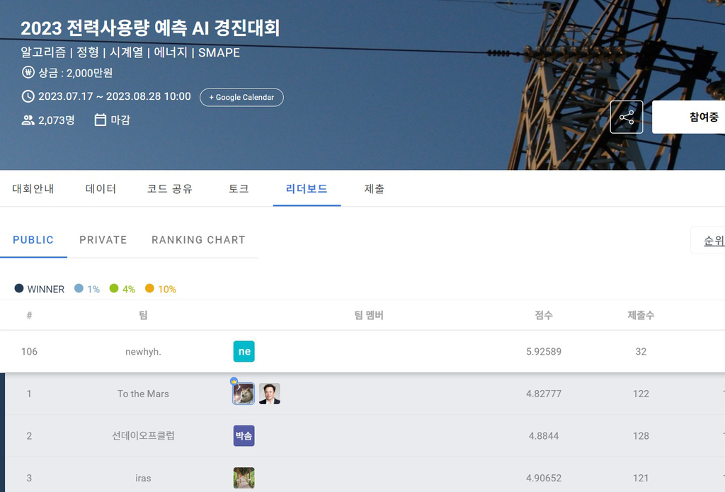

**라이브러리**

```r
library(tidyverse);library(caret);library(recipes);library(rsample);library(data.table)
library(corrplot);library(car);library(psych);library(lubridate);library(imputeTS)
library(lightgbm);library(tictoc);library(doParallel)
```

**train & test 데이터**

```r
path01 <- "./data/"
dat <- read.csv(file.path(path01, "train.csv"),encoding="UTF-8")
testdat <- read.csv(file.path(path01, "test.csv"),encoding="UTF-8")
dat %>% str();testdat  %>% str()
```

```
## 'data.frame':    204000 obs. of  10 variables:
##  $ num_date_time  : chr  "1_20220601 00" "1_20220601 01" "1_20220601 02" "1_20220601 03" ...
##  $ 건물번호       : int  1 1 1 1 1 1 1 1 1 1 ...
##  $ 일시           : chr  "20220601 00" "20220601 01" "20220601 02" "20220601 03" ...
##  $ 기온.C.        : num  18.6 18 17.7 16.7 18.4 17.2 16.3 17.4 20.6 23.2 ...
##  $ 강수량.mm.     : num  NA NA NA NA NA NA NA NA NA NA ...
##  $ 풍속.m.s.      : num  0.9 1.1 1.5 1.4 2.8 2.1 1 1.3 1.8 1.7 ...
##  $ 습도...        : num  42 45 45 48 43 46 50 50 44 41 ...
##  $ 일조.hr.       : num  NA NA NA NA NA NA 0 1 1 1 ...
##  $ 일사.MJ.m2.    : num  NA NA NA NA NA NA 0.05 0.55 1.29 2.01 ...
##  $ 전력소비량.kWh.: num  1085 1047 975 954 986 ...
```

```
## 'data.frame':    16800 obs. of  7 variables:
##  $ num_date_time: chr  "1_20220825 00" "1_20220825 01" "1_20220825 02" "1_20220825 03" ...
##  $ 건물번호     : int  1 1 1 1 1 1 1 1 1 1 ...
##  $ 일시         : chr  "20220825 00" "20220825 01" "20220825 02" "20220825 03" ...
##  $ 기온.C.      : num  23.5 23 22.7 22.1 21.8 21.6 21.5 21.7 22.3 22.7 ...
##  $ 강수량.mm.   : num  0 0 0 0 0 0 0 0 0 0 ...
##  $ 풍속.m.s.    : num  2.2 0.9 1.5 1.3 1 1.6 2.3 1.4 2.2 2.4 ...
##  $ 습도...      : int  72 72 75 78 77 81 84 83 82 78 ...
```

**건물 고유 식별 데이터**

```r
path <- "./data/"
build <- read.csv(file.path(path, "building_info.csv"),encoding="UTF-8")
build  %>% str()
```

```
## 'data.frame':    100 obs. of  7 variables:
##  $ 건물번호        : int  1 2 3 4 5 6 7 8 9 10 ...
##  $ 건물유형        : chr  "건물기타" "건물기타" "건물기타" "건물기타" ...
##  $ 연면적.m2.      : num  110634 122233 171243 74313 205884 ...
##  $ 냉방면적.m2.    : num  39570 99000 113950 34420 150000 ...
##  $ 태양광용량.kW.  : chr  "-" "-" "40" "60" ...
##  $ ESS저장용량.kWh.: chr  "-" "-" "-" "-" ...
##  $ PCS용량.kW.     : chr  "-" "-" "-" "-" ...
```

**데이터 구성 ================================================================**

**100개의 건물이 있는 지역의 시간별 환경 데이터**

설명변수 : 기온, 강수량, 습도, 풍속, 일사, 일조, 건물번호, 날짜시간  
반응변수 : 건물의 전력사용량  
train.csv : 6/1 ~8/24기간 24시간85일 데이터 X 100개의 건물  
test.csv : 8/25~8/31기간 24시간 7일 데이터 X 100개의 건물  
**각 건물의 고유 특성 데이터**  
건물 고유 특성 : 건물번호,건물유형,연면적,냉방면적,태양광용량kw,ESS저장용량kwh,PCS용량kw  
building_info.csv : 100개의 건물 고유 특성  
**데이터 이슈 ================================================================**

**환경변수 - ‘일사’ ‘일조’**  
환경 변수 중 ‘일사’ ‘일조’는 train데이터에만 존재. test데이터에는 없음.  
test데이터의 ’일사’ ’일조’를 시계열 예측으로 가능한지 검토 및 테스트 필요

**건물 고유 특성 변수**  
시간 데이터는 건물별로 동일하게 할당되어 있으므로 건물별로 학습을 진행 할 경우 건물 고유 변수는 데이터의 가치가 없어진다.

**머신러닝 학습 데이터 구분 ==================================================**  
1. 100개의 건물데이터를 전체 하나의 데이터로 한 머신러닝(학습데이터 수 : 204000, 머신러닝 1회 )  
2. 각 건물별 데이터를 머신러닝 후 결과를 합치기( 학습데이터 수 : 2040, 머신러닝 100회)  
수 차례 시행 결과 2번이 더 효율적이고 성능이 좋음.

**################################## 전처리 ##################################**  
**날짜, 시간 데이터 변수 분리 ================================================**

```r
date_li <- strsplit(dat$num_date_time, split= "_")
date_new <- c()
time_new <- c()
for(i in 1:length(date_li)){
  imtext <- date_li[[i]][2]
  date_new <- c( date_new ,substr(imtext,1,8) )
  time_new <- c( time_new ,substr(imtext,10,11) )
  }

date_new1 <- unclass(ymd(as.Date(date_new,format = '%Y%m%d'), tz='Asia/Seoul') ) + 32400
dat1 <- data.frame(dat,date_new = date_new1,time_new = as.numeric(time_new))

dat1 <-dat1 %>% select(-num_date_time)
```

**요일 추가**

```r
dat1$weekday <- wday( dat1$date_new )  # 숫자로 표시
dat1$weekday <- factor(dat1$weekday)
```

```r
dat2$date_new %>% head()
```

```
## [1] "2022-06-01" "2022-06-01" "2022-06-01" "2022-06-01" "2022-06-01"
## [6] "2022-06-01"
```

```r
dat2$time_new %>% head(24)
```

```
##  [1]  0  1  2  3  4  5  6  7  8  9 10 11 12 13 14 15 16 17 18 19 20 21 22 23
```

```r
dat2$weekday %>% head()
```

```
## [1] 4 4 4 4 4 4
## Levels: 1 2 3 4 5 6 7
```

**환경 데이터 변수 결측치 처리 ===============================================**

```r
dat2 %>% select( 건물번호,기온.C., 강수량.mm.,풍속.m.s.,습도...,일조.hr.,일사.MJ.m2.) %>% is.na() %>% colSums()
```

```
##    건물번호     기온.C.  강수량.mm.   풍속.m.s.     습도...    일조.hr.
##           0           0      160069          19           9       75182
## 일사.MJ.m2.
##       87913
```

**결측 대체 방법**

1.결측이 적은 비율의 변수는 건물별 데이터 구분, 시계열 대체  
2.결측이 많은 비율의 변수는 함수를 이용한 결측 대체

**‘일사’,’일조’는 test데이터에 없고, 결측 비율도 크므로 학습데이터에서 제외**  
(이 후 머신러닝에서 시계열 예측으로 포함된 데이터가 포함되지 않은 데이터보다 성능이 떨어짐 )

```r
dat2 <- dat2 %>% select(-c(일조.hr.,일사.MJ.m2.))
```

결측 대체 완료된 데이터 불러오기

```r
path02 <- "./rdata/"
load(file.path(path02, "dat3.RData") )
dat3 %>% is.na() %>% colSums()
```

```
##        건물번호            일시         기온.C.      강수량.mm.       풍속.m.s.
##               0               0               0               0               0
##         습도... 전력소비량.kWh.        date_new        time_new         weekday
##               0               0               0               0               0
```

**#################################### EDA ###################################**

**6,7,8월 여름철 기간 전력에 가장 큰 요인은 냉방기기 사용**

**냉방기기 사용량에 영향을 미치는 요인 확인===================================**

**주요 환경요인 : 기온,습도,강수량,불쾌지수**

불쾌지수는 데이터에 없다.  
기온과 습도로 ’불쾌지수 계산산식’을 통해 추정치 생성.

```r
기온 <- dat3$기온.C.
습도 <- dat3$습도...
불쾌지수 <- (1.8*기온)-(0.55*(1-습도)*(1.8*기온-26))+32
dat3$불쾌지수 <- 불쾌지수
dat3$불쾌지수%>% head()
```

```
## [1] 234.154 219.280 205.672 167.011 229.592 185.720
```

**건물유형 분포**

```r
build$건물유형 %>% table()
```

```
## .
##       건물기타           공공         대학교     데이터센터 백화점및아울렛
##             15              8              8              5              8
##           병원           상용         아파트         연구소   지식산업센터
##              8              8              8              8              8
##       할인마트   호텔및리조트
##              8              8
```

```r
for(i in 1:length(unique(build$건물유형))){
  print(unique(build$건물유형)[i])
 print( unique( build[build$건물유형== unique(build$건물유형)[i],'건물번호']) )
}
```

```
## [1] "건물기타"
##  [1]  1  2  3  4  5  6  7  8  9 10 11 12 13 14 15
## [1] "공공"
## [1] 16 17 18 19 20 21 22 23
## [1] "대학교"
## [1] 24 25 26 27 28 29 30 31
## [1] "데이터센터"
## [1] 32 33 34 35 36
## [1] "백화점및아울렛"
## [1] 37 38 39 40 41 42 43 44
## [1] "병원"
## [1] 45 46 47 48 49 50 51 52
## [1] "상용"
## [1] 53 54 55 56 57 58 59 60
## [1] "아파트"
## [1] 61 62 63 64 65 66 67 68
## [1] "연구소"
## [1] 69 70 71 72 73 74 75 76
## [1] "지식산업센터"
## [1] 77 78 79 80 81 82 83 84
## [1] "할인마트"
## [1] 85 86 87 88 89 90 91 92
## [1] "호텔및리조트"
## [1]  93  94  95  96  97  98  99 100
```

**많은 비중을 차지하는 3개의 건물유형에 대한 상관관계 확인**  
건물기타(건물번호:1),아파트(건물번호:61),할인마트(건물번호:85)

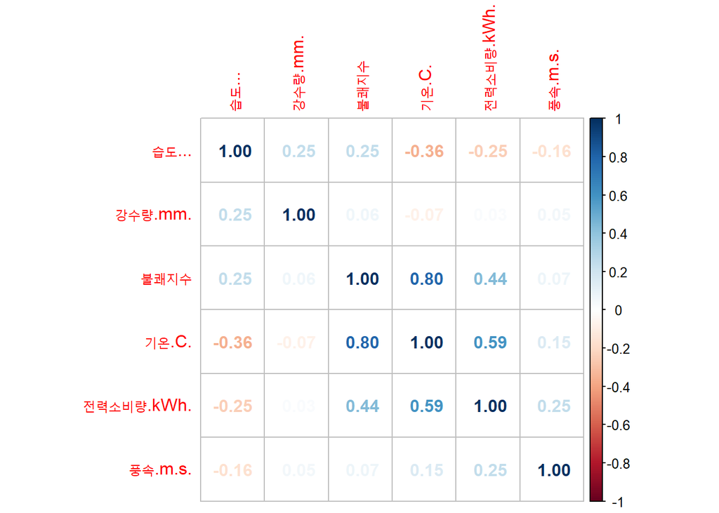

```r
M <- dat3[dat3$건물번호==1,] %>% select(전력소비량.kWh.,기온.C.,강수량.mm.,풍속.m.s.,습도...,불쾌지수) %>% cor()
M2 <- dat3[dat3$건물번호==61,] %>% select(전력소비량.kWh.,기온.C.,강수량.mm.,풍속.m.s.,습도...,불쾌지수) %>% cor()
M3 <- dat3[dat3$건물번호==85,] %>% select(전력소비량.kWh.,기온.C.,강수량.mm.,풍속.m.s.,습도...,불쾌지수) %>% cor()
corrplot(M,method="number", order="AOE" ) # 건물기타(건물번호:1)
```

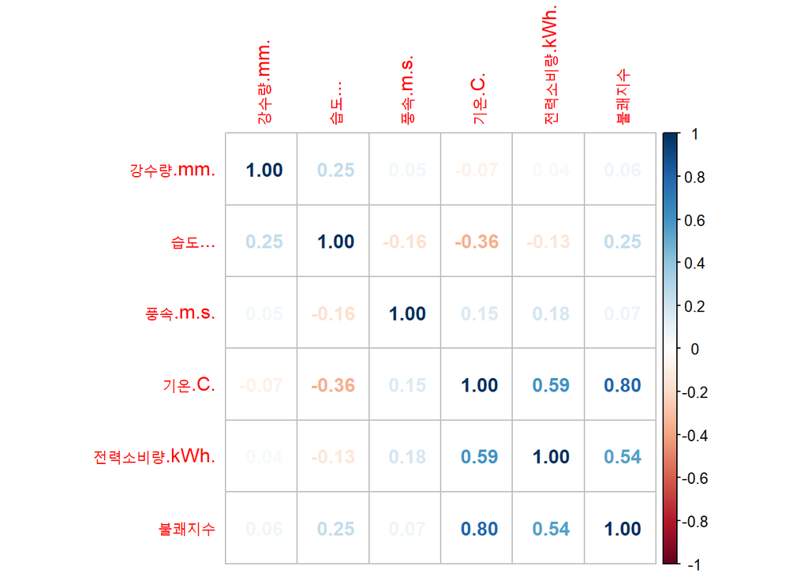

```r
corrplot(M2,method="number", order="AOE" )# 아파트(건물번호:61)
```

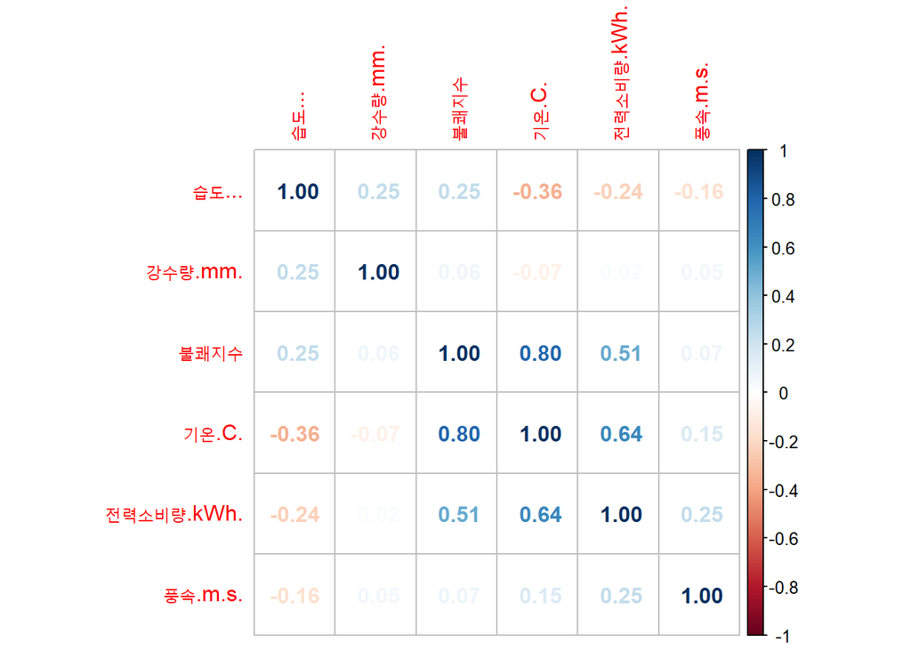

```r
corrplot(M3,method="number", order="AOE" )# 할인마트(건물번호:85)
```

**일별 환경 데이터 그래프=====================================================**  
건물별 일별 환경데이터 통계

```r
일별환경통계 <- dat3 %>% group_by(건물번호,date_new) %>% summarise( 전력소비량 = sum(전력소비량.kWh.),
                                                          기온 = mean(기온.C.),
                                                         습도 = mean(습도...),
                                                         풍속 = mean(풍속.m.s.),
                                                        불쾌지수 = mean(불쾌지수)) %>% as.data.frame()
```

가장많은 비중을 차지하는 건물유형인 ’기타건물’중 건물번호 1로 확인

```r
bdf <- 일별환경통계
bdf_p <- bdf[bdf$건물번호==1,]
```

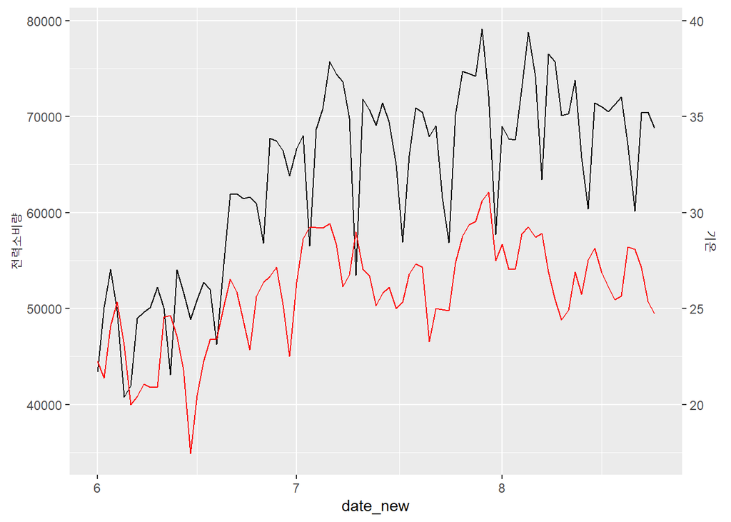

```r
ggplot(bdf_p ,aes(x=date_new)) + geom_line(aes(y=전력소비량)) +
  geom_line(aes(y=기온*2000),colour = "red") +
  scale_y_continuous(sec.axis = sec_axis(~./2000, name = "기온"))
```

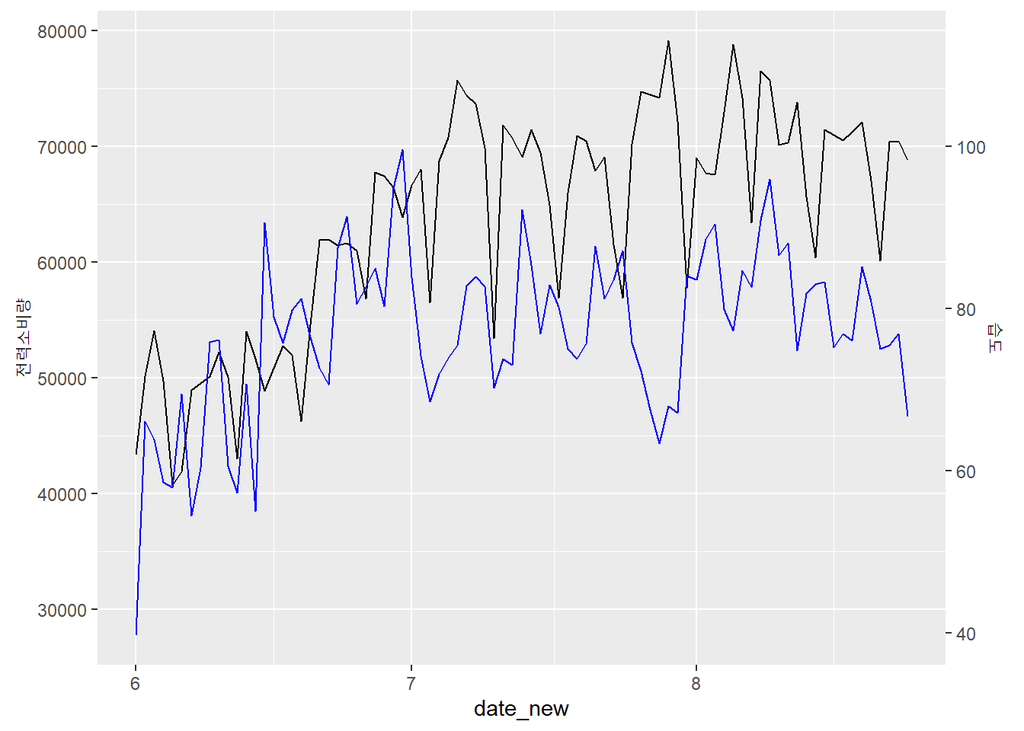

```r
ggplot(bdf_p ,aes(x=date_new)) + geom_line(aes(y=전력소비량)) +
  geom_line(aes(y=습도*700),colour = "blue") +
  scale_y_continuous(sec.axis = sec_axis(~./700, name = "습도"))
```

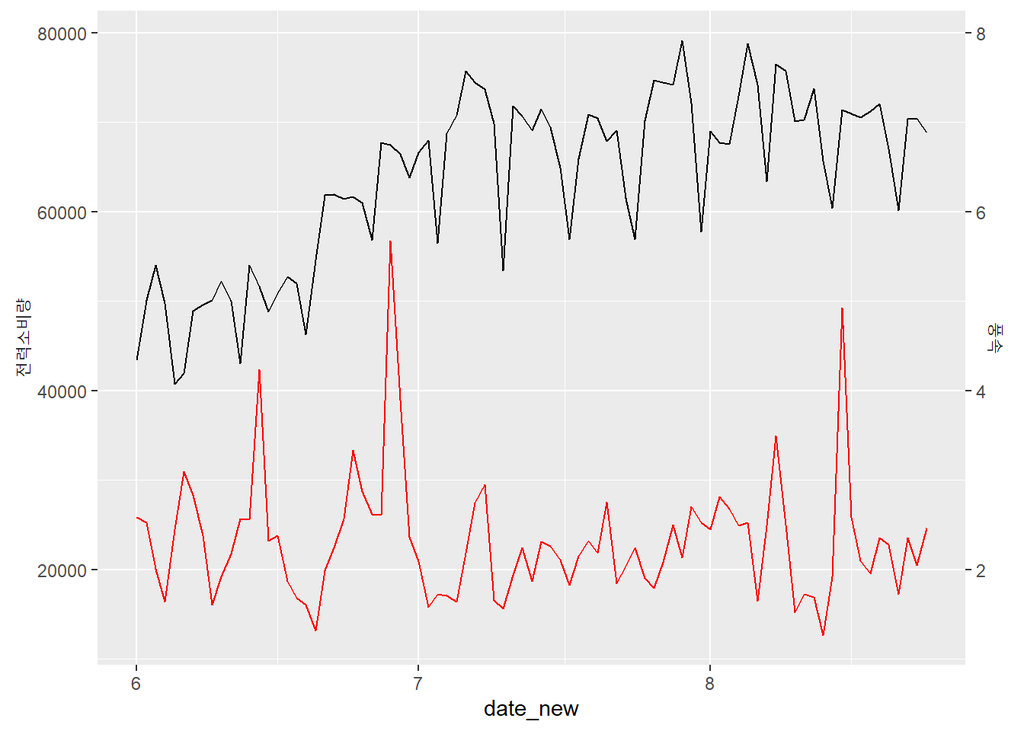

```r
ggplot(bdf_p ,aes(x=date_new)) + geom_line(aes(y=전력소비량)) +
  geom_line(aes(y=풍속*10000),colour = "red") +
  scale_y_continuous(sec.axis = sec_axis(~./10000, name = "풍속"))
```

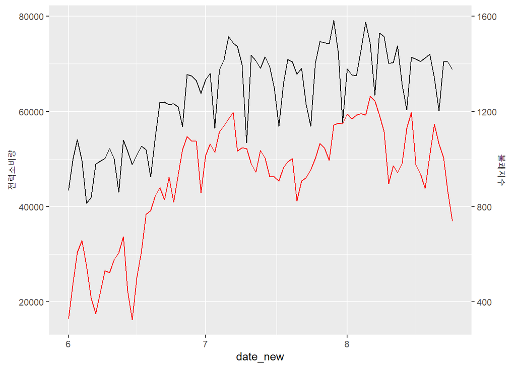

```r
ggplot(bdf_p ,aes(x=date_new)) + geom_line(aes(y=전력소비량)) +
  geom_line(aes(y=불쾌지수*50),colour = "red") +
  scale_y_continuous(sec.axis = sec_axis(~./50, name = "불쾌지수"))
```

기온과 불쾌지수는 대체로 전력소비량의 패턴과 비슷하다.  
습도는 비슷한 구간과 그렇지 않은 구간 모두 존재한다.  
반면 풍속은 전력소비량과의 패턴이 전혀 다르다.

**최종 환경 변수 선택=========================================================**  
상관계수와 비교 그래프에서 상관성이 거의 없어 보이는 강수량과 풍속을 제외한다.  
습도는 추후 머신러닝 주요변수 확인을 통해서 결과를 주요변수 여부를 확인한다.  
( 이후 머신러닝에서 습도는 주요도가 낮은 변수로 판명됨.)

```r
dat3 <- dat3 %>% select(-c(강수량.mm.,풍속.m.s.,습도...))
```

**############################### 추가 변수 생성 #############################**

**기온 & 불쾌지수 일최고, 일최저, 일평균 추가 ================================**

```r
건물별통계 <- dat3 %>% group_by(건물번호,date_new)%>% summarise(
                                                           기온_일최저 = min(기온.C.),
                                                           기온_일최고 = max(기온.C.),
                                                           기온_일평균 = mean(기온.C.))
dat3 <- left_join(dat3,건물별통계[,c('건물번호','date_new','기온_일최저','기온_일최고','기온_일평균')],by=c('건물번호','date_new' ) )
```

```r
건물별통계 <- dat3 %>% group_by(건물번호,date_new)%>% summarise(
                                                           불쾌지수_일최저 = min(불쾌지수),
                                                           불쾌지수_일최고 = max(불쾌지수),
                                                           불쾌지수_일평균 = mean(불쾌지수) )
dat3 <- left_join(dat3,건물별통계[,c('건물번호','date_new','불쾌지수_일최저','불쾌지수_일최고','불쾌지수_일평균')],by=c('건물번호','date_new' ) )
```

**날짜 순번 변수 추가 =========================================================**  
머신러닝의 경우 ’날짜’의 데이터 타입이 적용될 수 없으므로 이에 대응하는 날짜순번 변수를 생성.

```r
날짜순번 <- c()
for(i in 1:85){날짜순번 <- c(날짜순번, rep(i,24)) }
날짜순번100 <-  rep(날짜순번,100)
dat3$날짜순번 <- 날짜순번100

dat3 <- dat3 %>% select(-일시) # 불필요한 변수 삭제
#기타 처리
dat3$건물번호 <- factor( dat3$건물번호 )
dat3$날짜순번 <- as.numeric(dat3$날짜순번)

train <- dat3 %>% as.data.frame()
```

**TEST 데이터 ================================================================**  
train 데이터와 동일한 전처리를 한 test데이터 불러오기

```r
path <- "./rdata/"
load(file.path(path, "test_전처리.RData"))
```

```r
test %>% str()
```

```
## 'data.frame':    16800 obs. of  13 variables:
##  $ 건물번호       : Factor w/ 100 levels "1","2","3","4",..: 1 1 1 1 1 1 1 1 1 1 ...
##  $ 기온.C.        : num  23.5 23 22.7 22.1 21.8 21.6 21.5 21.7 22.3 22.7 ...
##  $ date_new       : Date, format: "2022-08-25" "2022-08-25" ...
##  $ time_new       : num  0 1 2 3 4 5 6 7 8 9 ...
##  $ weekday        : Factor w/ 7 levels "1","2","3","4",..: 5 5 5 5 5 5 5 5 5 5 ...
##  $ 불쾌지수       : num  711 675 678 655 625 ...
##  $ 날짜순번       : num  86 86 86 86 86 86 86 86 86 86 ...
##  $ 기온_일최저    : num  21.2 21.2 21.2 21.2 21.2 21.2 21.2 21.2 21.2 21.2 ...
##  $ 기온_일최고    : num  24 24 24 24 24 24 24 24 24 24 ...
##  $ 기온_일평균    : num  22.4 22.4 22.4 22.4 22.4 ...
##  $ 불쾌지수_일최저: num  542 542 542 542 542 ...
##  $ 불쾌지수_일최고: num  825 825 825 825 825 ...
##  $ 불쾌지수_일평균: num  682 682 682 682 682 ...
```

```r
train %>% str()
```

```
## 'data.frame':    204000 obs. of  14 variables:
##  $ 건물번호       : Factor w/ 100 levels "1","2","3","4",..: 1 1 1 1 1 1 1 1 1 1 ...
##  $ 기온.C.        : num  18.6 18 17.7 16.7 18.4 17.2 16.3 17.4 20.6 23.2 ...
##  $ 전력소비량.kWh.: num  1085 1047 975 954 986 ...
##  $ date_new       : Date, format: "2022-06-01" "2022-06-01" ...
##  $ time_new       : num  0 1 2 3 4 5 6 7 8 9 ...
##  $ weekday        : Factor w/ 7 levels "1","2","3","4",..: 4 4 4 4 4 4 4 4 4 4 ...
##  $ 불쾌지수       : num  234 219 206 167 230 ...
##  $ 기온_일최저    : num  16.3 16.3 16.3 16.3 16.3 16.3 16.3 16.3 16.3 16.3 ...
##  $ 기온_일최고    : num  28.4 28.4 28.4 28.4 28.4 28.4 28.4 28.4 28.4 28.4 ...
##  $ 기온_일평균    : num  22.3 22.3 22.3 22.3 22.3 ...
##  $ 불쾌지수_일최저: num  151 151 151 151 151 ...
##  $ 불쾌지수_일최고: num  447 447 447 447 447 ...
##  $ 불쾌지수_일평균: num  328 328 328 328 328 ...
##  $ 날짜순번       : num  1 1 1 1 1 1 1 1 1 1 ...
```

**1차 머신러닝 결과 =========================================================**

**########################## 날짜 시간 추가변수 생성 #########################**  
1. 평일 휴일 공휴일 구분-범주형 변수 생성  
2. 날짜+시간 정수형 변수 생성  
3. weeknum(~주차 순번) 범주형 변수 생성  
4. 3번 weeknum범주에 따른 평균기온, 평균불쾌지수 생성

**평일 휴일 공휴일 구분 =====================================================**  
건물전체 : 1.”평일” 2.”주말휴일”, 3.”공휴일”  
할인 마트: “마트휴일” 6/12 6/26 7/10 7/24 8/14 8/28  
평일 휴일

```r
train$공휴일 <- rep("평일",nrow(train))
test$공휴일 <- rep("평일",nrow(test))

train[train$weekday==1 | train$weekday==7,"공휴일"] <- "주말휴일"
test[test$weekday==1 | test$weekday==7,"공휴일"] <- "주말휴일"
```

공휴일

```r
공휴일 <- c("2022-06-01","2022-06-06","2022-08-15") # test 해당없음.
for(i in 1:length(공휴일) ){
train[train$date_new == as.Date(공휴일[i]),"공휴일"] <- "공휴일" }
```

할인마트 정기휴일 : 건물번호 85~92

```r
마트휴일 <- c("2022-06-12","2022-06-26","2022-07-10","2022-07-24","2022-08-14","2022-08-28")
for(i in 85:92){
  for(j in 1:length(마트휴일)){
  train[train$건물번호==i & train$date_new == as.Date(마트휴일[j]) ,"공휴일"] <- "마트휴일"
  test[test$건물번호==i & test$date_new == as.Date(마트휴일[j]) ,"공휴일"] <- "마트휴일" } }
```

```r
전체공휴일 <- c(train$공휴일,test$공휴일)
전체공휴일 <- factor(전체공휴일)
```

```r
train$공휴일 <- 전체공휴일[1:204000]
test$공휴일 <- 전체공휴일[204001:length(전체공휴일)]

train$공휴일 %>% levels()
```

```
## [1] "공휴일"   "마트휴일" "주말휴일" "평일"
```

```r
test$공휴일 %>% levels()
```

```
## [1] "공휴일"   "마트휴일" "주말휴일" "평일"
```

**날짜+시간 정수형 변수 ======================================================**

```r
time <- c()
for(i in 1:length(train$time_new)){
  if(train$time_new[i]<10){
    time <- c(time,paste0("0",as.character(train$time_new[i]) )  )
  }else{ time <- c(time,as.character(train$time_new[i])) } }

date_time <- unclass(as.POSIXct(paste0(train$date_new," ",time,":00:00")) )
train$date_time <- date_time
```

TEST데이터에도 동일 변수 생성

**weeknum(~주차 순번) 범주형 변수 생성 =======================================**

```r
# train===============================
주간순번 <- c()
for(i in 1:11){ 주간순번 <- c(주간순번,rep(i,(7*24))) }
주간순번 <- c(rep(0,96),주간순번,rep(12,96))
train$weeknum <- 주간순번
# test===============================
주간순번_1 <- c(rep(12,72),rep(13,96))
test$weeknum <- 주간순번_1
```

```r
weeknum <- c(train$weeknum,test$weeknum)
weeknum <- factor(weeknum)

train$weeknum <- weeknum[1:204000]
test$weeknum <- weeknum[204001:length(weeknum)]
```

**weeknum 범주별(~주차) 평균기온==============================================**

```r
weektemp <- c()
for(i in 1:100){
  train_p <- train[train$건물번호==i,]
  wtemp <- c()
  for(j in 0:12){
    tempmwan <- mean(train_p[train_p$weeknum==j,"기온.C."])
    if(j==0|j==12){
      wtemp <- c(wtemp,  rep(tempmwan,(4*24))  )
    }else{wtemp <- c(wtemp,  rep(tempmwan,(7*24)) )}}
  weektemp <- c(weektemp,wtemp) }
train$weektemp <- weektemp
```

TEST데이터에도 동일 변수 생성

**weeknum 범주별(~주차) 평균불쾌지수 =========================================**

```r
week불쾌지수 <- c()
for(i in 1:100){
  train_p <- train[train$건물번호==i,]
  wtemp <- c()
  for(j in 0:12){
    tempmwan <- mean(train_p[train_p$weeknum==j,"불쾌지수"])
    if(j==0|j==12){
      wtemp <- c(wtemp,  rep(tempmwan,(4*24))  )
    }else{wtemp <- c(wtemp,  rep(tempmwan,(7*24)) )}}
  week불쾌지수 <- c(week불쾌지수,wtemp) }
train$week불쾌지수 <- week불쾌지수
```

TEST데이터에도 동일 변수 생성

**반응변수 박스콕스 변환======================================================**  
반응변수 분포 확인

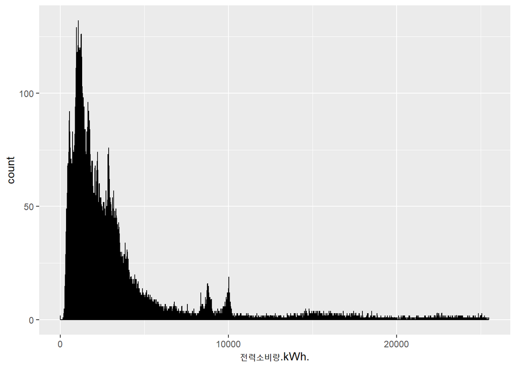

```r
train %>% ggplot( aes(x=전력소비량.kWh. )) + geom_histogram(colour="black", binwidth=1)
```

오른꼬리 분포이다.

**제곱근 변환**

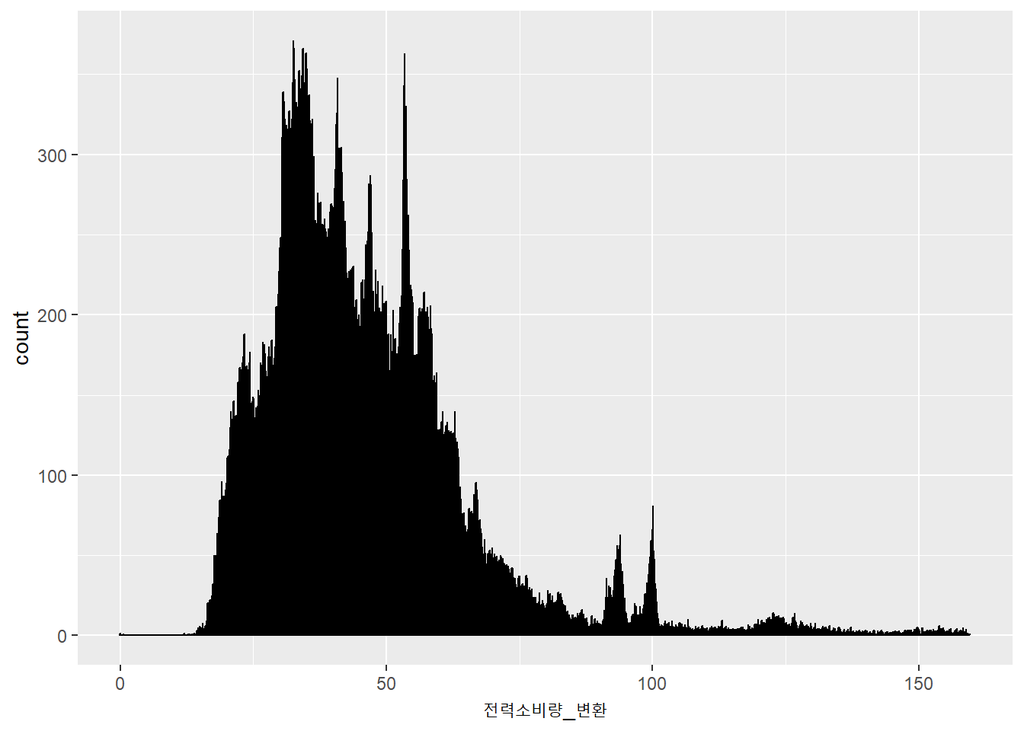

```r
전력소비량_변환 <- sqrt(train$전력소비량.kWh.)
data.frame(전력소비량_변환) %>% ggplot( aes(x=전력소비량_변환 )) + geom_histogram(colour="black", binwidth=0.05)
```

정규분포와 유사한 형태가 되었다.

```r
train$전력소비량.kWh. <- 전력소비량_변환
```

**최종 학습 데이터**

```r
train %>% str()
```

```
## 'data.frame':    204000 obs. of  19 variables:
##  $ 기온.C.        : num  18.6 18 17.7 16.7 18.4 17.2 16.3 17.4 20.6 23.2 ...
##  $ 기온_일최고    : num  28.4 28.4 28.4 28.4 28.4 28.4 28.4 28.4 28.4 28.4 ...
##  $ date_new       : Date, format: "2022-06-01" "2022-06-01" ...
##  $ 날짜순번       : int  1 1 1 1 1 1 1 1 1 1 ...
##  $ time_new       : num  0 1 2 3 4 5 6 7 8 9 ...
##  $ 건물번호       : Factor w/ 100 levels "1","2","3","4",..: 1 1 1 1 1 1 1 1 1 1 ...
##  $ 전력소비량.kWh.: num  32.9 32.4 31.2 30.9 31.4 ...
##  $ weekday        : Factor w/ 7 levels "1","2","3","4",..: 4 4 4 4 4 4 4 4 4 4 ...
##  $ date_time      : num  1.65e+09 1.65e+09 1.65e+09 1.65e+09 1.65e+09 ...
##   ..- attr(*, "tzone")= chr ""
##  $ 기온_일최저    : num  16.3 16.3 16.3 16.3 16.3 16.3 16.3 16.3 16.3 16.3 ...
##  $ weeknum        : Factor w/ 14 levels "0","1","2","3",..: 1 1 1 1 1 1 1 1 1 1 ...
##  $ weektemp       : num  23.3 23.3 23.3 23.3 23.3 ...
##  $ 기온_일평균    : num  22.3 22.3 22.3 22.3 22.3 ...
##  $ 불쾌지수       : num  234 219 206 167 230 ...
##  $ 공휴일         : Factor w/ 4 levels "공휴일","마트휴일",..: 1 1 1 1 1 1 1 1 1 1 ...
##  $ 불쾌지수_일최저: num  151 151 151 151 151 ...
##  $ 불쾌지수_일최고: num  447 447 447 447 447 ...
##  $ 불쾌지수_일평균: num  328 328 328 328 328 ...
##  $ week불쾌지수   : num  519 519 519 519 519 ...
```

```r
test %>% str()
```

```
## 'data.frame':    16800 obs. of  18 variables:
##  $ 기온.C.        : num  23.5 23 22.7 22.1 21.8 21.6 21.5 21.7 22.3 22.7 ...
##  $ 기온_일최고    : num  24 24 24 24 24 24 24 24 24 24 ...
##  $ date_new       : Date, format: "2022-08-25" "2022-08-25" ...
##  $ 날짜순번       : num  86 86 86 86 86 86 86 86 86 86 ...
##  $ time_new       : num  0 1 2 3 4 5 6 7 8 9 ...
##  $ 건물번호       : Factor w/ 100 levels "1","2","3","4",..: 1 1 1 1 1 1 1 1 1 1 ...
##  $ weekday        : Factor w/ 7 levels "1","2","3","4",..: 5 5 5 5 5 5 5 5 5 5 ...
##  $ date_time      : num  1.66e+09 1.66e+09 1.66e+09 1.66e+09 1.66e+09 ...
##   ..- attr(*, "tzone")= chr ""
##  $ 기온_일최저    : num  21.2 21.2 21.2 21.2 21.2 21.2 21.2 21.2 21.2 21.2 ...
##  $ weeknum        : Factor w/ 14 levels "0","1","2","3",..: 13 13 13 13 13 13 13 13 13 13 ...
##  $ weektemp       : num  22.6 22.6 22.6 22.6 22.6 ...
##  $ 기온_일평균    : num  22.4 22.4 22.4 22.4 22.4 ...
##  $ 불쾌지수       : num  711 675 678 655 625 ...
##  $ 공휴일         : Factor w/ 4 levels "공휴일","마트휴일",..: 4 4 4 4 4 4 4 4 4 4 ...
##  $ 불쾌지수_일최저: num  542 542 542 542 542 ...
##  $ 불쾌지수_일최고: num  825 825 825 825 825 ...
##  $ 불쾌지수_일평균: num  682 682 682 682 682 ...
##  $ week불쾌지수   : num  633 633 633 633 633 ...
```

**################################## 머신러닝 ################################**  
**머신러닝 알고리즘**  
1.CATBOOST  
2.랜덤포레스트  
3.XGBOOST  
범주형 변수가 많아 처음 CATBOOST로 학습하였지만 랜럼포레스트나 XGBOOST에 비해 성능이 크게 떨어진 결과였다.  
수 차례 학습에서 XGBOOST가 랜덤포레스트보다 좀 더 우수한 성능으로 결과가 나왔다.  
**건물별 머신러닝을 100회 시행하여 결과를 취합함.**  
1. 건물별 예측 데이터 취합  
2. 건물별 모델 객체 데이터 취합(변수 중요도 확인을 위한)  
‘date_new’,’건물번호’는 머신러닝에서 제외한다.

```r
grid <- expand.grid(
  nrounds = c(100,300,600),
  max_depth =c(2,4,6),
  eta = c(0.01,0.1,0.2),
  gamma = c(0.7,0.5, 0.25),
  colsample_bytree =1,
  min_child_weight =1,
  subsample = c(0.5,0.75,1.0)
)
control <- trainControl(method="cv",number=10)
cl <- makePSOCKcluster(18)
```

```r
tic()
registerDoParallel(cl)
pred_xgb_all <- c()
xgb_all <- list()

for(i in 1:100){
train_p <- train[train$건물번호==i,]
test_p  <- test[test$건물번호==i,]

rec_p <- train_p %>%
  recipe(전력소비량.kWh. ~ .) %>%
  step_rm(date_new,건물번호) %>%
  step_dummy(all_nominal_predictors()) %>%
  step_normalize(all_numeric_predictors())

xgb_p            <- train(rec_p, data = train_p,
                       method = 'xgbTree',
                        metric = 'RMSE',
                       tuneGrid = grid,
                       trControl = control
                       )
xgb_all[[i]] <- xgb_p

pred_xgb_p <- predict(xgb_p, newdata = test_p)
pred_xgb <- pred_xgb_p^2
pred_xgb_all <- c(pred_xgb_all,pred_xgb)

print(paste0(i," 번째 완료"))
}
toc()
stopCluster(cl)
```

취합된 예측 데이터

```r
pred_xgb_all %>% head(10)
```

```
##  [1] 1986.201 1906.243 1795.242 1632.249 1682.171 1823.182 2104.532 2339.732
##  [9] 2781.224 3207.715
```

**변수 중요도 ================================================================**  
건물별로 학습을 하였으므로 각 건물별 변수 중요도는 다르다.  
따라서 각 건물별 모델 결과에서 특정 비중(%) 이상을 차지하는 변수들의 수 합산으로 표시하게 한다.  
1. 1%이상~10%미만 비중을 차지하는 변수의 수  
2. 10% 이상 비중을 차지하는 변수의 수

```r
xgb_all <- 모델_xgb_0906_1_100
vi_var <- as.data.frame(matrix(1:10, nrow = 1, ncol = 10, byrow = T ))
vi_pro <- as.data.frame(matrix(1:10, nrow = 1, ncol = 10, byrow = T ))

for(i in 1:100){
  vi <- varImp(xgb_all[[i]],scale = T)
  var <- rownames(arrange(vi$importance,desc(Overall)))[1:10]
  var1 <- as.data.frame(matrix(var, nrow = 1, ncol = 10, byrow = T ))
  vi_var <- rbind(vi_var,var1)

  pro <- arrange(vi$importance,desc(Overall))[1:10,]
  pro1 <- as.data.frame(matrix(pro, nrow = 1, ncol = 10, byrow = T ))
  vi_pro <- rbind(vi_pro,pro1)
}
vi_var <- vi_var[-1,]
vi_pro <- vi_pro[-1,]
zero_li <- list()
zero_var <- c()
for(i in 1:ncol(vi_pro)){
  zero_li[[i]] <-  vi_var[which(vi_pro[,i]>=1 & vi_pro[,i]<10),i]
  zero_var <- c(zero_var, vi_var[which(vi_pro[,i]>=1 & vi_pro[,i]<10),i])
}
zero_li2 <- list()
zero_var2 <- c()
for(i in 1:ncol(vi_pro)){
  zero_li2[[i]] <-  vi_var[which(vi_pro[,i]>=10),i]
  zero_var2 <- c(zero_var2, vi_var[which(vi_pro[,i]>=10),i])
}
zero_var %>% table()
zero_var2 %>% table()
```

```
## .
##       date_time        time_new      weekday_X2      weekday_X4      weekday_X6
##              52               3               5               1               2
##      weekday_X7      weeknum_X2      weeknum_X3        weektemp    week불쾌지수
##               7               1               1              10              10
## 공휴일_마트휴일 공휴일_주말휴일     공휴일_평일     기온_일최고     기온_일최저
##               3              17               8              25              20
##     기온_일평균         기온.C.        날짜순번        불쾌지수 불쾌지수_일최고
##              16              45              30              42              28
## 불쾌지수_일최저 불쾌지수_일평균
##              13              11
```

```
## .
##       date_time        time_new      weekday_X2      weekday_X6      weekday_X7
##              26              97               2               1               1
##      weeknum_X5        weektemp    week불쾌지수 공휴일_마트휴일 공휴일_주말휴일
##               1               1               1               3               3
##     공휴일_평일     기온_일최고     기온_일최저     기온_일평균         기온.C.
##              46               5               2               2              33
##        날짜순번        불쾌지수 불쾌지수_일최고 불쾌지수_일최저 불쾌지수_일평균
##               4              27               8               4               4
```

**중요도 1%이상~10%미만 비중을 차지하는 변수**  
date_time:52, 기온:45, 불쾌지수:42, 날짜순번:30, 불쾌지수_일최고:28 순이다.  
**중요도 10%이상 비중을 차지하는 변수**  
time_new:97, 공휴일_평일:46, 기온:33, 불쾌지수:27, date_time:26 순이다.